# Risk Factor Analysis

## Outcome Variable

**Outcome Variable:** y_rate_haz

## Predictor Variables

**Intervention Variable:** pers_wast

**Adjustment Set:**

- arm
- sex
- W_mage
- meducyrs
- W_mhtcm
- W_nrooms
- month
- brthmon
- impfloor
- delta_W_mage
- delta_meducyrs
- delta_W_mhtcm
- delta_W_nrooms
- delta_month
- delta_brthmon
- delta_impfloor

## Stratifying Variables

The analysis was stratified on these variable(s):

- agecat
- studyid
- country

## Data Summary

| agecat | studyid | country | pers_wast | n_cell | n |
| --- | --- | --- | --- | --- | --- |
| 0-3 months | ki0047075b-MAL-ED | BANGLADESH | 0 | 237 | 244 |
| 0-3 months | ki0047075b-MAL-ED | BANGLADESH | 1 | 7 | 244 |
| 0-3 months | ki1017093b-PROVIDE | BANGLADESH | 0 | 619 | 634 |
| 0-3 months | ki1017093b-PROVIDE | BANGLADESH | 1 | 15 | 634 |
| 0-3 months | ki1114097-CMIN | BANGLADESH | 0 | 41 | 43 |
| 0-3 months | ki1114097-CMIN | BANGLADESH | 1 | 2 | 43 |
| 0-3 months | ki0047075b-MAL-ED | BRAZIL | 0 | 180 | 180 |
| 0-3 months | ki1101329-Keneba | GAMBIA | 0 | 1246 | 1276 |
| 0-3 months | ki1101329-Keneba | GAMBIA | 1 | 30 | 1276 |
| 0-3 months | ki0047075b-MAL-ED | INDIA | 0 | 187 | 201 |
| 0-3 months | ki0047075b-MAL-ED | INDIA | 1 | 14 | 201 |
| 0-3 months | ki1000108-CMC-V-BCS-2002 | INDIA | 0 | 78 | 87 |
| 0-3 months | ki1000108-CMC-V-BCS-2002 | INDIA | 1 | 9 | 87 |
| 0-3 months | ki1000108-IRC | INDIA | 0 | 310 | 377 |
| 0-3 months | ki1000108-IRC | INDIA | 1 | 67 | 377 |
| 0-3 months | ki0047075b-MAL-ED | NEPAL | 0 | 172 | 175 |
| 0-3 months | ki0047075b-MAL-ED | NEPAL | 1 | 3 | 175 |
| 0-3 months | ki1000109-EE | PAKISTAN | 0 | 277 | 297 |
| 0-3 months | ki1000109-EE | PAKISTAN | 1 | 20 | 297 |
| 0-3 months | ki1000109-ResPak | PAKISTAN | 0 | 69 | 78 |
| 0-3 months | ki1000109-ResPak | PAKISTAN | 1 | 9 | 78 |
| 0-3 months | ki0047075b-MAL-ED | PERU | 0 | 271 | 271 |
| 0-3 months | ki1114097-CMIN | PERU | 0 | 89 | 93 |
| 0-3 months | ki1114097-CMIN | PERU | 1 | 4 | 93 |
| 0-3 months | ki1114097-CONTENT | PERU | 0 | 29 | 29 |
| 0-3 months | ki0047075b-MAL-ED | SOUTH AFRICA | 0 | 227 | 229 |
| 0-3 months | ki0047075b-MAL-ED | SOUTH AFRICA | 1 | 2 | 229 |
| 0-3 months | ki0047075b-MAL-ED | TANZANIA, UNITED REPUBLIC OF | 0 | 229 | 229 |
| 3-6 months | ki0047075b-MAL-ED | BANGLADESH | 0 | 226 | 231 |
| 3-6 months | ki0047075b-MAL-ED | BANGLADESH | 1 | 5 | 231 |

[output cut: 94 more lines]

The following strata were considered:

- agecat: 0-3 months, studyid: ki0047075b-MAL-ED, country: BANGLADESH
- agecat: 0-3 months, studyid: ki0047075b-MAL-ED, country: BRAZIL
- agecat: 0-3 months, studyid: ki0047075b-MAL-ED, country: INDIA
- agecat: 0-3 months, studyid: ki0047075b-MAL-ED, country: NEPAL
- agecat: 0-3 months, studyid: ki0047075b-MAL-ED, country: PERU
- agecat: 0-3 months, studyid: ki0047075b-MAL-ED, country: SOUTH AFRICA
- agecat: 0-3 months, studyid: ki0047075b-MAL-ED, country: TANZANIA, UNITED REPUBLIC OF
- agecat: 0-3 months, studyid: ki1000108-CMC-V-BCS-2002, country: INDIA
- agecat: 0-3 months, studyid: ki1000108-IRC, country: INDIA
- agecat: 0-3 months, studyid: ki1000109-EE, country: PAKISTAN
- agecat: 0-3 months, studyid: ki1000109-ResPak, country: PAKISTAN
- agecat: 0-3 months, studyid: ki1017093b-PROVIDE, country: BANGLADESH
- agecat: 0-3 months, studyid: ki1101329-Keneba, country: GAMBIA
- agecat: 0-3 months, studyid: ki1114097-CMIN, country: BANGLADESH
- agecat: 0-3 months, studyid: ki1114097-CMIN, country: PERU
- agecat: 0-3 months, studyid: ki1114097-CONTENT, country: PERU
- agecat: 12-24 months, studyid: ki0047075b-MAL-ED, country: BANGLADESH
- agecat: 12-24 months, studyid: ki0047075b-MAL-ED, country: BRAZIL
- agecat: 12-24 months, studyid: ki0047075b-MAL-ED, country: INDIA
- agecat: 12-24 months, studyid: ki0047075b-MAL-ED, country: NEPAL
- agecat: 12-24 months, studyid: ki0047075b-MAL-ED, country: PERU
- agecat: 12-24 months, studyid: ki0047075b-MAL-ED, country: SOUTH AFRICA
- agecat: 12-24 months, studyid: ki0047075b-MAL-ED, country: TANZANIA, UNITED REPUBLIC OF
- agecat: 12-24 months, studyid: ki1000108-CMC-V-BCS-2002, country: INDIA
- agecat: 12-24 months, studyid: ki1000108-IRC, country: INDIA
- agecat: 12-24 months, studyid: ki1017093b-PROVIDE, country: BANGLADESH
- agecat: 12-24 months, studyid: ki1066203-TanzaniaChild2, country: TANZANIA, UNITED REPUBLIC OF
- agecat: 12-24 months, studyid: ki1101329-Keneba, country: GAMBIA
- agecat: 12-24 months, studyid: ki1113344-GMS-Nepal, country: NEPAL
- agecat: 12-24 months, studyid: ki1114097-CMIN, country: BANGLADESH
- agecat: 12-24 months, studyid: ki1114097-CMIN, country: PERU
- agecat: 12-24 months, studyid: ki1114097-CONTENT, country: PERU
- agecat: 3-6 months, studyid: ki0047075b-MAL-ED, country: BANGLADESH
- agecat: 3-6 months, studyid: ki0047075b-MAL-ED, country: BRAZIL
- agecat: 3-6 months, studyid: ki0047075b-MAL-ED, country: INDIA
- agecat: 3-6 months, studyid: ki0047075b-MAL-ED, country: NEPAL
- agecat: 3-6 months, studyid: ki0047075b-MAL-ED, country: PERU
- agecat: 3-6 months, studyid: ki0047075b-MAL-ED, country: SOUTH AFRICA
- agecat: 3-6 months, studyid: ki0047075b-MAL-ED, country: TANZANIA, UNITED REPUBLIC OF
- agecat: 3-6 months, studyid: ki1000108-CMC-V-BCS-2002, country: INDIA
- agecat: 3-6 months, studyid: ki1000108-IRC, country: INDIA
- agecat: 3-6 months, studyid: ki1000109-EE, country: PAKISTAN
- agecat: 3-6 months, studyid: ki1000109-ResPak, country: PAKISTAN
- agecat: 3-6 months, studyid: ki1017093b-PROVIDE, country: BANGLADESH
- agecat: 3-6 months, studyid: ki1066203-TanzaniaChild2, country: TANZANIA, UNITED REPUBLIC OF
- agecat: 3-6 months, studyid: ki1101329-Keneba, country: GAMBIA
- agecat: 3-6 months, studyid: ki1113344-GMS-Nepal, country: NEPAL
- agecat: 3-6 months, studyid: ki1114097-CMIN, country: BANGLADESH
- agecat: 3-6 months, studyid: ki1114097-CMIN, country: PERU
- agecat: 3-6 months, studyid: ki1114097-CONTENT, country: PERU
- agecat: 6-12 months, studyid: ki0047075b-MAL-ED, country: BANGLADESH
- agecat: 6-12 months, studyid: ki0047075b-MAL-ED, country: BRAZIL
- agecat: 6-12 months, studyid: ki0047075b-MAL-ED, country: INDIA
- agecat: 6-12 months, studyid: ki0047075b-MAL-ED, country: NEPAL
- agecat: 6-12 months, studyid: ki0047075b-MAL-ED, country: PERU
- agecat: 6-12 months, studyid: ki0047075b-MAL-ED, country: SOUTH AFRICA
- agecat: 6-12 months, studyid: ki0047075b-MAL-ED, country: TANZANIA, UNITED REPUBLIC OF
- agecat: 6-12 months, studyid: ki1000108-CMC-V-BCS-2002, country: INDIA
- agecat: 6-12 months, studyid: ki1000108-IRC, country: INDIA
- agecat: 6-12 months, studyid: ki1000109-EE, country: PAKISTAN
- agecat: 6-12 months, studyid: ki1000109-ResPak, country: PAKISTAN
- agecat: 6-12 months, studyid: ki1017093b-PROVIDE, country: BANGLADESH
- agecat: 6-12 months, studyid: ki1066203-TanzaniaChild2, country: TANZANIA, UNITED REPUBLIC OF
- agecat: 6-12 months, studyid: ki1101329-Keneba, country: GAMBIA
- agecat: 6-12 months, studyid: ki1112895-Guatemala BSC, country: GUATEMALA
- agecat: 6-12 months, studyid: ki1113344-GMS-Nepal, country: NEPAL
- agecat: 6-12 months, studyid: ki1114097-CMIN, country: BANGLADESH
- agecat: 6-12 months, studyid: ki1114097-CMIN, country: PERU
- agecat: 6-12 months, studyid: ki1114097-CONTENT, country: PERU

### Dropped Strata

Some strata were dropped due to rare outcomes:

- agecat: 0-3 months, studyid: ki1114097-CMIN, country: BANGLADESH
- agecat: 0-3 months, studyid: ki0047075b-MAL-ED, country: NEPAL
- agecat: 0-3 months, studyid: ki1114097-CMIN, country: PERU
- agecat: 0-3 months, studyid: ki0047075b-MAL-ED, country: SOUTH AFRICA
- agecat: 3-6 months, studyid: ki0047075b-MAL-ED, country: BRAZIL
- agecat: 3-6 months, studyid: ki0047075b-MAL-ED, country: NEPAL
- agecat: 3-6 months, studyid: ki0047075b-MAL-ED, country: SOUTH AFRICA
- agecat: 6-12 months, studyid: ki0047075b-MAL-ED, country: BRAZIL
- agecat: 6-12 months, studyid: ki1112895-Guatemala BSC, country: GUATEMALA
- agecat: 6-12 months, studyid: ki0047075b-MAL-ED, country: NEPAL
- agecat: 6-12 months, studyid: ki1000109-EE, country: PAKISTAN
- agecat: 6-12 months, studyid: ki0047075b-MAL-ED, country: SOUTH AFRICA
- agecat: 12-24 months, studyid: ki1114097-CMIN, country: BANGLADESH
- agecat: 12-24 months, studyid: ki0047075b-MAL-ED, country: BRAZIL
- agecat: 12-24 months, studyid: ki0047075b-MAL-ED, country: NEPAL
- agecat: 12-24 months, studyid: ki1114097-CMIN, country: PERU
- agecat: 12-24 months, studyid: ki0047075b-MAL-ED, country: SOUTH AFRICA
- agecat: 12-24 months, studyid: ki1066203-TanzaniaChild2, country: TANZANIA, UNITED REPUBLIC OF

## Methods Detail

We’re interested in the causal parameters $E[Y_a]$ for all values of $a \in \mathcal{A}$. These parameters represent the mean outcome if, possibly contrary to fact, we intervened to set all units to have $A=a$. Under the randomization and positivity assumptions, these are identified by the statistical parameters $\psi_a=E_W[E_{Y|A,W}(Y|A=a,W)]$. In addition, we’re interested in the mean of $Y$, $E[Y]$ under no intervention (the observed mean). We will estimate these parameters by using SuperLearner to fit the relevant likelihood factors – $E_{Y|A,W}(Y|A=a,W)$ and $p(A=a|W)$, and then updating our likelihood fit using a joint TMLE.

For unadjusted analyses ($W=\{\}$), initial likelihoods were estimated using Lrnr_glm to estimate the simple $E(Y|A)$ and Lrnr_mean to estimate $p(A)$. For adjusted analyses, a small library containing Lrnr_glmnet, Lrnr_xgboost, and Lrnr_mean was used.

[output not shown]

[output cut: 3017 more lines]

[output not shown]

# Results Detail

## Results Plots

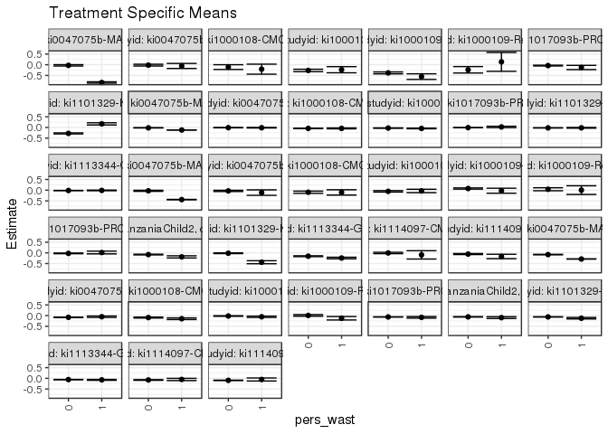

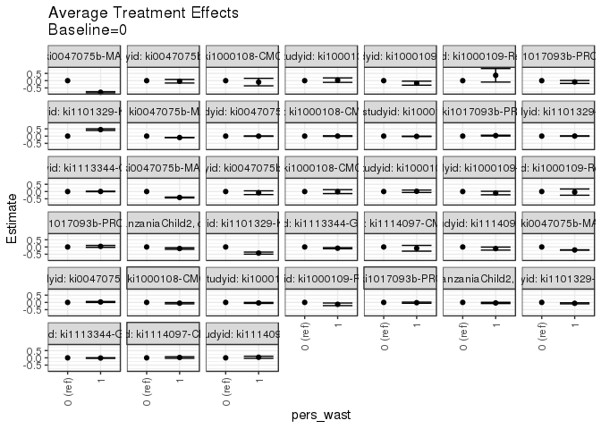

## Results Table

### Parameter: TSM

| agecat | studyid | country | intervention_level | baseline_level | estimate | ci_lower | ci_upper |
| --- | --- | --- | --- | --- | --- | --- | --- |
| 0-3 months | ki0047075b-MAL-ED | BANGLADESH | 0 | NA | -0.0288677 | -0.0606802 | 0.0029447 |
| 0-3 months | ki0047075b-MAL-ED | BANGLADESH | 1 | NA | -0.8301095 | -0.8609486 | -0.7992704 |
| 0-3 months | ki0047075b-MAL-ED | INDIA | 0 | NA | -0.0177525 | -0.0589215 | 0.0234166 |
| 0-3 months | ki0047075b-MAL-ED | INDIA | 1 | NA | -0.0569083 | -0.1747131 | 0.0608965 |
| 0-3 months | ki1000108-CMC-V-BCS-2002 | INDIA | 0 | NA | -0.1093744 | -0.2200366 | 0.0012878 |
| 0-3 months | ki1000108-CMC-V-BCS-2002 | INDIA | 1 | NA | -0.2065755 | -0.4413335 | 0.0281825 |
| 0-3 months | ki1000108-IRC | INDIA | 0 | NA | -0.2680793 | -0.3256279 | -0.2105306 |
| 0-3 months | ki1000108-IRC | INDIA | 1 | NA | -0.2319530 | -0.3754428 | -0.0884632 |
| 0-3 months | ki1000109-EE | PAKISTAN | 0 | NA | -0.3822557 | -0.4266069 | -0.3379045 |
| 0-3 months | ki1000109-EE | PAKISTAN | 1 | NA | -0.5544653 | -0.6858132 | -0.4231174 |
| 0-3 months | ki1000109-ResPak | PAKISTAN | 0 | NA | -0.2362023 | -0.3866052 | -0.0857993 |
| 0-3 months | ki1000109-ResPak | PAKISTAN | 1 | NA | 0.1339200 | -0.3078040 | 0.5756439 |
| 0-3 months | ki1017093b-PROVIDE | BANGLADESH | 0 | NA | -0.0392330 | -0.0574269 | -0.0210391 |
| 0-3 months | ki1017093b-PROVIDE | BANGLADESH | 1 | NA | -0.1283180 | -0.2279434 | -0.0286925 |
| 0-3 months | ki1101329-Keneba | GAMBIA | 0 | NA | -0.2785443 | -0.3022578 | -0.2548309 |
| 0-3 months | ki1101329-Keneba | GAMBIA | 1 | NA | 0.1689453 | 0.1173729 | 0.2205177 |
| 3-6 months | ki0047075b-MAL-ED | BANGLADESH | 0 | NA | -0.0301009 | -0.0541389 | -0.0060628 |
| 3-6 months | ki0047075b-MAL-ED | BANGLADESH | 1 | NA | -0.4403090 | -0.4497899 | -0.4308280 |
| 3-6 months | ki0047075b-MAL-ED | INDIA | 0 | NA | -0.0337599 | -0.0621736 | -0.0053463 |
| 3-6 months | ki0047075b-MAL-ED | INDIA | 1 | NA | -0.1138002 | -0.2412947 | 0.0136944 |
| 3-6 months | ki1000108-CMC-V-BCS-2002 | INDIA | 0 | NA | -0.0969074 | -0.1485081 | -0.0453066 |
| 3-6 months | ki1000108-CMC-V-BCS-2002 | INDIA | 1 | NA | -0.1042623 | -0.2279999 | 0.0194752 |
| 3-6 months | ki1000108-IRC | INDIA | 0 | NA | -0.0550858 | -0.0873094 | -0.0228621 |
| 3-6 months | ki1000108-IRC | INDIA | 1 | NA | -0.0364458 | -0.1153159 | 0.0424244 |
| 3-6 months | ki1000109-EE | PAKISTAN | 0 | NA | 0.0776152 | 0.0489792 | 0.1062512 |
| 3-6 months | ki1000109-EE | PAKISTAN | 1 | NA | -0.0252739 | -0.1427354 | 0.0921877 |
| 3-6 months | ki1000109-ResPak | PAKISTAN | 0 | NA | 0.0421991 | -0.0278903 | 0.1122886 |
| 3-6 months | ki1000109-ResPak | PAKISTAN | 1 | NA | 0.0024896 | -0.2006609 | 0.2056401 |
| 3-6 months | ki1017093b-PROVIDE | BANGLADESH | 0 | NA | -0.0239236 | -0.0402812 | -0.0075660 |
| 3-6 months | ki1017093b-PROVIDE | BANGLADESH | 1 | NA | 0.0170494 | -0.0471426 | 0.0812413 |
| 3-6 months | ki1066203-TanzaniaChild2 | TANZANIA, UNITED REPUBLIC OF | 0 | NA | -0.0800364 | -0.0967817 | -0.0632910 |
| 3-6 months | ki1066203-TanzaniaChild2 | TANZANIA, UNITED REPUBLIC OF | 1 | NA | -0.1867170 | -0.2376874 | -0.1357465 |
| 3-6 months | ki1101329-Keneba | GAMBIA | 0 | NA | -0.0152161 | -0.0335893 | 0.0031572 |
| 3-6 months | ki1101329-Keneba | GAMBIA | 1 | NA | -0.4372693 | -0.5073516 | -0.3671869 |
| 3-6 months | ki1113344-GMS-Nepal | NEPAL | 0 | NA | -0.1548320 | -0.1744954 | -0.1351685 |
| 3-6 months | ki1113344-GMS-Nepal | NEPAL | 1 | NA | -0.2398591 | -0.2751243 | -0.2045939 |
| 3-6 months | ki1114097-CMIN | BANGLADESH | 0 | NA | -0.0037601 | -0.0359144 | 0.0283941 |
| 3-6 months | ki1114097-CMIN | BANGLADESH | 1 | NA | -0.0936021 | -0.2883811 | 0.1011769 |
| 3-6 months | ki1114097-CMIN | PERU | 0 | NA | -0.0556745 | -0.0783125 | -0.0330366 |
| 3-6 months | ki1114097-CMIN | PERU | 1 | NA | -0.1677108 | -0.2695951 | -0.0658265 |
| 6-12 months | ki0047075b-MAL-ED | BANGLADESH | 0 | NA | -0.0798107 | -0.0901590 | -0.0694623 |
| 6-12 months | ki0047075b-MAL-ED | BANGLADESH | 1 | NA | -0.2868500 | -0.2912023 | -0.2824976 |
| 6-12 months | ki0047075b-MAL-ED | INDIA | 0 | NA | -0.0812739 | -0.0932767 | -0.0692710 |
| 6-12 months | ki0047075b-MAL-ED | INDIA | 1 | NA | -0.0523041 | -0.0862613 | -0.0183469 |
| 6-12 months | ki1000108-CMC-V-BCS-2002 | INDIA | 0 | NA | -0.0928858 | -0.1152995 | -0.0704721 |
| 6-12 months | ki1000108-CMC-V-BCS-2002 | INDIA | 1 | NA | -0.1456523 | -0.1837321 | -0.1075725 |
| 6-12 months | ki1000108-IRC | INDIA | 0 | NA | -0.0191341 | -0.0325072 | -0.0057611 |
| 6-12 months | ki1000108-IRC | INDIA | 1 | NA | -0.0552668 | -0.0863061 | -0.0242275 |
| 6-12 months | ki1000109-ResPak | PAKISTAN | 0 | NA | 0.0082271 | -0.0308213 | 0.0472755 |
| 6-12 months | ki1000109-ResPak | PAKISTAN | 1 | NA | -0.1242672 | -0.2048189 | -0.0437155 |
| 6-12 months | ki1017093b-PROVIDE | BANGLADESH | 0 | NA | -0.0632871 | -0.0702775 | -0.0562967 |
| 6-12 months | ki1017093b-PROVIDE | BANGLADESH | 1 | NA | -0.0830350 | -0.1202680 | -0.0458020 |
| 6-12 months | ki1066203-TanzaniaChild2 | TANZANIA, UNITED REPUBLIC OF | 0 | NA | -0.0588083 | -0.0681173 | -0.0494993 |
| 6-12 months | ki1066203-TanzaniaChild2 | TANZANIA, UNITED REPUBLIC OF | 1 | NA | -0.0955519 | -0.1368002 | -0.0543036 |
| 6-12 months | ki1101329-Keneba | GAMBIA | 0 | NA | -0.0614415 | -0.0692327 | -0.0536502 |
| 6-12 months | ki1101329-Keneba | GAMBIA | 1 | NA | -0.1226850 | -0.1574751 | -0.0878949 |
| 6-12 months | ki1113344-GMS-Nepal | NEPAL | 0 | NA | -0.0598857 | -0.0685165 | -0.0512549 |
| 6-12 months | ki1113344-GMS-Nepal | NEPAL | 1 | NA | -0.0726414 | -0.0926756 | -0.0526073 |
| 6-12 months | ki1114097-CMIN | BANGLADESH | 0 | NA | -0.0775181 | -0.0927225 | -0.0623137 |
| 6-12 months | ki1114097-CMIN | BANGLADESH | 1 | NA | -0.0533863 | -0.1065897 | -0.0001828 |
| 6-12 months | ki1114097-CMIN | PERU | 0 | NA | -0.0953703 | -0.1058687 | -0.0848718 |
| 6-12 months | ki1114097-CMIN | PERU | 1 | NA | -0.0553901 | -0.1264480 | 0.0156678 |
| 12-24 months | ki0047075b-MAL-ED | BANGLADESH | 0 | NA | -0.0184812 | -0.0239197 | -0.0130427 |
| 12-24 months | ki0047075b-MAL-ED | BANGLADESH | 1 | NA | -0.1182445 | -0.1217537 | -0.1147352 |
| 12-24 months | ki0047075b-MAL-ED | INDIA | 0 | NA | -0.0106028 | -0.0158414 | -0.0053642 |
| 12-24 months | ki0047075b-MAL-ED | INDIA | 1 | NA | -0.0133612 | -0.0255187 | -0.0012037 |
| 12-24 months | ki1000108-CMC-V-BCS-2002 | INDIA | 0 | NA | -0.0449468 | -0.0560605 | -0.0338331 |
| 12-24 months | ki1000108-CMC-V-BCS-2002 | INDIA | 1 | NA | -0.0434027 | -0.0638993 | -0.0229060 |
| 12-24 months | ki1000108-IRC | INDIA | 0 | NA | -0.0280883 | -0.0355402 | -0.0206363 |
| 12-24 months | ki1000108-IRC | INDIA | 1 | NA | -0.0466495 | -0.0620613 | -0.0312377 |
| 12-24 months | ki1017093b-PROVIDE | BANGLADESH | 0 | NA | -0.0089751 | -0.0128052 | -0.0051449 |
| 12-24 months | ki1017093b-PROVIDE | BANGLADESH | 1 | NA | 0.0244716 | -0.0068134 | 0.0557566 |
| 12-24 months | ki1101329-Keneba | GAMBIA | 0 | NA | -0.0202444 | -0.0241536 | -0.0163351 |
| 12-24 months | ki1101329-Keneba | GAMBIA | 1 | NA | -0.0170495 | -0.0337891 | -0.0003099 |
| 12-24 months | ki1113344-GMS-Nepal | NEPAL | 0 | NA | -0.0161508 | -0.0212660 | -0.0110357 |
| 12-24 months | ki1113344-GMS-Nepal | NEPAL | 1 | NA | -0.0107485 | -0.0251390 | 0.0036421 |

### Parameter: E(Y)

| agecat | studyid | country | intervention_level | baseline_level | estimate | ci_lower | ci_upper |
| --- | --- | --- | --- | --- | --- | --- | --- |
| 0-3 months | ki0047075b-MAL-ED | BANGLADESH | NA | NA | -0.0339062 | -0.0659795 | -0.0018330 |
| 0-3 months | ki0047075b-MAL-ED | INDIA | NA | NA | -0.0204797 | -0.0596747 | 0.0187152 |
| 0-3 months | ki1000108-CMC-V-BCS-2002 | INDIA | NA | NA | -0.0732952 | -0.1806423 | 0.0340519 |
| 0-3 months | ki1000108-IRC | INDIA | NA | NA | -0.2594964 | -0.3154509 | -0.2035418 |
| 0-3 months | ki1000109-EE | PAKISTAN | NA | NA | -0.3938516 | -0.4364614 | -0.3512419 |
| 0-3 months | ki1000109-ResPak | PAKISTAN | NA | NA | -0.1934958 | -0.3384003 | -0.0485914 |
| 0-3 months | ki1017093b-PROVIDE | BANGLADESH | NA | NA | -0.0413143 | -0.0594662 | -0.0231624 |
| 0-3 months | ki1101329-Keneba | GAMBIA | NA | NA | -0.2850538 | -0.3091443 | -0.2609633 |
| 3-6 months | ki0047075b-MAL-ED | BANGLADESH | NA | NA | -0.0225211 | -0.0456381 | 0.0005960 |
| 3-6 months | ki0047075b-MAL-ED | INDIA | NA | NA | -0.0401251 | -0.0685271 | -0.0117231 |
| 3-6 months | ki1000108-CMC-V-BCS-2002 | INDIA | NA | NA | -0.0979615 | -0.1455947 | -0.0503283 |
| 3-6 months | ki1000108-IRC | INDIA | NA | NA | -0.0518918 | -0.0819849 | -0.0217987 |
| 3-6 months | ki1000109-EE | PAKISTAN | NA | NA | 0.0701161 | 0.0419135 | 0.0983187 |
| 3-6 months | ki1000109-ResPak | PAKISTAN | NA | NA | 0.0387792 | -0.0275800 | 0.1051384 |
| 3-6 months | ki1017093b-PROVIDE | BANGLADESH | NA | NA | -0.0272428 | -0.0436954 | -0.0107902 |
| 3-6 months | ki1066203-TanzaniaChild2 | TANZANIA, UNITED REPUBLIC OF | NA | NA | -0.0844665 | -0.1011169 | -0.0678162 |
| 3-6 months | ki1101329-Keneba | GAMBIA | NA | NA | -0.0167995 | -0.0352345 | 0.0016355 |
| 3-6 months | ki1113344-GMS-Nepal | NEPAL | NA | NA | -0.1659967 | -0.1845182 | -0.1474752 |
| 3-6 months | ki1114097-CMIN | BANGLADESH | NA | NA | -0.0085806 | -0.0411510 | 0.0239898 |
| 3-6 months | ki1114097-CMIN | PERU | NA | NA | -0.0576273 | -0.0800097 | -0.0352449 |
| 6-12 months | ki0047075b-MAL-ED | BANGLADESH | NA | NA | -0.0807393 | -0.0911050 | -0.0703737 |
| 6-12 months | ki0047075b-MAL-ED | INDIA | NA | NA | -0.0776724 | -0.0898619 | -0.0654829 |
| 6-12 months | ki1000108-CMC-V-BCS-2002 | INDIA | NA | NA | -0.1005481 | -0.1211684 | -0.0799278 |
| 6-12 months | ki1000108-IRC | INDIA | NA | NA | -0.0260151 | -0.0389122 | -0.0131180 |
| 6-12 months | ki1000109-ResPak | PAKISTAN | NA | NA | -0.0070783 | -0.0435451 | 0.0293884 |
| 6-12 months | ki1017093b-PROVIDE | BANGLADESH | NA | NA | -0.0626151 | -0.0695574 | -0.0556729 |
| 6-12 months | ki1066203-TanzaniaChild2 | TANZANIA, UNITED REPUBLIC OF | NA | NA | -0.0598587 | -0.0690454 | -0.0506721 |
| 6-12 months | ki1101329-Keneba | GAMBIA | NA | NA | -0.0617247 | -0.0695829 | -0.0538665 |
| 6-12 months | ki1113344-GMS-Nepal | NEPAL | NA | NA | -0.0614960 | -0.0697225 | -0.0532696 |
| 6-12 months | ki1114097-CMIN | BANGLADESH | NA | NA | -0.0773003 | -0.0921728 | -0.0624278 |
| 6-12 months | ki1114097-CMIN | PERU | NA | NA | -0.0939324 | -0.1044393 | -0.0834255 |
| 12-24 months | ki0047075b-MAL-ED | BANGLADESH | NA | NA | -0.0178490 | -0.0232486 | -0.0124494 |
| 12-24 months | ki0047075b-MAL-ED | INDIA | NA | NA | -0.0098833 | -0.0150187 | -0.0047479 |
| 12-24 months | ki1000108-CMC-V-BCS-2002 | INDIA | NA | NA | -0.0447636 | -0.0549912 | -0.0345359 |
| 12-24 months | ki1000108-IRC | INDIA | NA | NA | -0.0317687 | -0.0388357 | -0.0247017 |
| 12-24 months | ki1017093b-PROVIDE | BANGLADESH | NA | NA | -0.0081718 | -0.0120131 | -0.0043304 |
| 12-24 months | ki1101329-Keneba | GAMBIA | NA | NA | -0.0201603 | -0.0240062 | -0.0163144 |
| 12-24 months | ki1113344-GMS-Nepal | NEPAL | NA | NA | -0.0155649 | -0.0206065 | -0.0105234 |

### Parameter: ATE

| agecat | studyid | country | intervention_level | baseline_level | estimate | ci_lower | ci_upper |
| --- | --- | --- | --- | --- | --- | --- | --- |
| 0-3 months | ki0047075b-MAL-ED | BANGLADESH | 0 | 0 | 0.0000000 | 0.0000000 | 0.0000000 |
| 0-3 months | ki0047075b-MAL-ED | BANGLADESH | 1 | 0 | -0.8012418 | -0.8452293 | -0.7572543 |
| 0-3 months | ki0047075b-MAL-ED | INDIA | 0 | 0 | 0.0000000 | 0.0000000 | 0.0000000 |
| 0-3 months | ki0047075b-MAL-ED | INDIA | 1 | 0 | -0.0391558 | -0.1639471 | 0.0856355 |
| 0-3 months | ki1000108-CMC-V-BCS-2002 | INDIA | 0 | 0 | 0.0000000 | 0.0000000 | 0.0000000 |
| 0-3 months | ki1000108-CMC-V-BCS-2002 | INDIA | 1 | 0 | -0.0972011 | -0.3553243 | 0.1609222 |
| 0-3 months | ki1000108-IRC | INDIA | 0 | 0 | 0.0000000 | 0.0000000 | 0.0000000 |
| 0-3 months | ki1000108-IRC | INDIA | 1 | 0 | 0.0361262 | -0.1169983 | 0.1892507 |
| 0-3 months | ki1000109-EE | PAKISTAN | 0 | 0 | 0.0000000 | 0.0000000 | 0.0000000 |
| 0-3 months | ki1000109-EE | PAKISTAN | 1 | 0 | -0.1722096 | -0.3107271 | -0.0336920 |
| 0-3 months | ki1000109-ResPak | PAKISTAN | 0 | 0 | 0.0000000 | 0.0000000 | 0.0000000 |
| 0-3 months | ki1000109-ResPak | PAKISTAN | 1 | 0 | 0.3701222 | -0.0965051 | 0.8367496 |
| 0-3 months | ki1017093b-PROVIDE | BANGLADESH | 0 | 0 | 0.0000000 | 0.0000000 | 0.0000000 |
| 0-3 months | ki1017093b-PROVIDE | BANGLADESH | 1 | 0 | -0.0890850 | -0.1896807 | 0.0115107 |
| 0-3 months | ki1101329-Keneba | GAMBIA | 0 | 0 | 0.0000000 | 0.0000000 | 0.0000000 |
| 0-3 months | ki1101329-Keneba | GAMBIA | 1 | 0 | 0.4474896 | 0.3911330 | 0.5038463 |
| 3-6 months | ki0047075b-MAL-ED | BANGLADESH | 0 | 0 | 0.0000000 | 0.0000000 | 0.0000000 |
| 3-6 months | ki0047075b-MAL-ED | BANGLADESH | 1 | 0 | -0.4102081 | -0.4381860 | -0.3822302 |
| 3-6 months | ki0047075b-MAL-ED | INDIA | 0 | 0 | 0.0000000 | 0.0000000 | 0.0000000 |
| 3-6 months | ki0047075b-MAL-ED | INDIA | 1 | 0 | -0.0800402 | -0.2103216 | 0.0502411 |
| 3-6 months | ki1000108-CMC-V-BCS-2002 | INDIA | 0 | 0 | 0.0000000 | 0.0000000 | 0.0000000 |
| 3-6 months | ki1000108-CMC-V-BCS-2002 | INDIA | 1 | 0 | -0.0073550 | -0.1414137 | 0.1267038 |
| 3-6 months | ki1000108-IRC | INDIA | 0 | 0 | 0.0000000 | 0.0000000 | 0.0000000 |
| 3-6 months | ki1000108-IRC | INDIA | 1 | 0 | 0.0186400 | -0.0661679 | 0.1034479 |
| 3-6 months | ki1000109-EE | PAKISTAN | 0 | 0 | 0.0000000 | 0.0000000 | 0.0000000 |
| 3-6 months | ki1000109-EE | PAKISTAN | 1 | 0 | -0.1028891 | -0.2234913 | 0.0177131 |
| 3-6 months | ki1000109-ResPak | PAKISTAN | 0 | 0 | 0.0000000 | 0.0000000 | 0.0000000 |
| 3-6 months | ki1000109-ResPak | PAKISTAN | 1 | 0 | -0.0397095 | -0.2547187 | 0.1752996 |
| 3-6 months | ki1017093b-PROVIDE | BANGLADESH | 0 | 0 | 0.0000000 | 0.0000000 | 0.0000000 |
| 3-6 months | ki1017093b-PROVIDE | BANGLADESH | 1 | 0 | 0.0409730 | -0.0245530 | 0.1064990 |
| 3-6 months | ki1066203-TanzaniaChild2 | TANZANIA, UNITED REPUBLIC OF | 0 | 0 | 0.0000000 | 0.0000000 | 0.0000000 |
| 3-6 months | ki1066203-TanzaniaChild2 | TANZANIA, UNITED REPUBLIC OF | 1 | 0 | -0.1066806 | -0.1600845 | -0.0532767 |
| 3-6 months | ki1101329-Keneba | GAMBIA | 0 | 0 | 0.0000000 | 0.0000000 | 0.0000000 |
| 3-6 months | ki1101329-Keneba | GAMBIA | 1 | 0 | -0.4220532 | -0.4942325 | -0.3498739 |
| 3-6 months | ki1113344-GMS-Nepal | NEPAL | 0 | 0 | 0.0000000 | 0.0000000 | 0.0000000 |
| 3-6 months | ki1113344-GMS-Nepal | NEPAL | 1 | 0 | -0.0850272 | -0.1250734 | -0.0449810 |
| 3-6 months | ki1114097-CMIN | BANGLADESH | 0 | 0 | 0.0000000 | 0.0000000 | 0.0000000 |
| 3-6 months | ki1114097-CMIN | BANGLADESH | 1 | 0 | -0.0898419 | -0.2872487 | 0.1075648 |
| 3-6 months | ki1114097-CMIN | PERU | 0 | 0 | 0.0000000 | 0.0000000 | 0.0000000 |
| 3-6 months | ki1114097-CMIN | PERU | 1 | 0 | -0.1120363 | -0.2162756 | -0.0077969 |
| 6-12 months | ki0047075b-MAL-ED | BANGLADESH | 0 | 0 | 0.0000000 | 0.0000000 | 0.0000000 |
| 6-12 months | ki0047075b-MAL-ED | BANGLADESH | 1 | 0 | -0.2070393 | -0.2183035 | -0.1957751 |
| 6-12 months | ki0047075b-MAL-ED | INDIA | 0 | 0 | 0.0000000 | 0.0000000 | 0.0000000 |
| 6-12 months | ki0047075b-MAL-ED | INDIA | 1 | 0 | 0.0289698 | -0.0057155 | 0.0636550 |
| 6-12 months | ki1000108-CMC-V-BCS-2002 | INDIA | 0 | 0 | 0.0000000 | 0.0000000 | 0.0000000 |
| 6-12 months | ki1000108-CMC-V-BCS-2002 | INDIA | 1 | 0 | -0.0527665 | -0.0967472 | -0.0087859 |
| 6-12 months | ki1000108-IRC | INDIA | 0 | 0 | 0.0000000 | 0.0000000 | 0.0000000 |
| 6-12 months | ki1000108-IRC | INDIA | 1 | 0 | -0.0361327 | -0.0696084 | -0.0026569 |
| 6-12 months | ki1000109-ResPak | PAKISTAN | 0 | 0 | 0.0000000 | 0.0000000 | 0.0000000 |
| 6-12 months | ki1000109-ResPak | PAKISTAN | 1 | 0 | -0.1324943 | -0.2219792 | -0.0430094 |
| 6-12 months | ki1017093b-PROVIDE | BANGLADESH | 0 | 0 | 0.0000000 | 0.0000000 | 0.0000000 |
| 6-12 months | ki1017093b-PROVIDE | BANGLADESH | 1 | 0 | -0.0197479 | -0.0576170 | 0.0181212 |
| 6-12 months | ki1066203-TanzaniaChild2 | TANZANIA, UNITED REPUBLIC OF | 0 | 0 | 0.0000000 | 0.0000000 | 0.0000000 |
| 6-12 months | ki1066203-TanzaniaChild2 | TANZANIA, UNITED REPUBLIC OF | 1 | 0 | -0.0367436 | -0.0787645 | 0.0052773 |
| 6-12 months | ki1101329-Keneba | GAMBIA | 0 | 0 | 0.0000000 | 0.0000000 | 0.0000000 |
| 6-12 months | ki1101329-Keneba | GAMBIA | 1 | 0 | -0.0612436 | -0.0967837 | -0.0257034 |
| 6-12 months | ki1113344-GMS-Nepal | NEPAL | 0 | 0 | 0.0000000 | 0.0000000 | 0.0000000 |
| 6-12 months | ki1113344-GMS-Nepal | NEPAL | 1 | 0 | -0.0127557 | -0.0343810 | 0.0088695 |
| 6-12 months | ki1114097-CMIN | BANGLADESH | 0 | 0 | 0.0000000 | 0.0000000 | 0.0000000 |
| 6-12 months | ki1114097-CMIN | BANGLADESH | 1 | 0 | 0.0241318 | -0.0308529 | 0.0791165 |
| 6-12 months | ki1114097-CMIN | PERU | 0 | 0 | 0.0000000 | 0.0000000 | 0.0000000 |
| 6-12 months | ki1114097-CMIN | PERU | 1 | 0 | 0.0399801 | -0.0318434 | 0.1118037 |
| 12-24 months | ki0047075b-MAL-ED | BANGLADESH | 0 | 0 | 0.0000000 | 0.0000000 | 0.0000000 |
| 12-24 months | ki0047075b-MAL-ED | BANGLADESH | 1 | 0 | -0.0997632 | -0.1063308 | -0.0931957 |
| 12-24 months | ki0047075b-MAL-ED | INDIA | 0 | 0 | 0.0000000 | 0.0000000 | 0.0000000 |
| 12-24 months | ki0047075b-MAL-ED | INDIA | 1 | 0 | -0.0027584 | -0.0155063 | 0.0099895 |
| 12-24 months | ki1000108-CMC-V-BCS-2002 | INDIA | 0 | 0 | 0.0000000 | 0.0000000 | 0.0000000 |
| 12-24 months | ki1000108-CMC-V-BCS-2002 | INDIA | 1 | 0 | 0.0015441 | -0.0213940 | 0.0244822 |
| 12-24 months | ki1000108-IRC | INDIA | 0 | 0 | 0.0000000 | 0.0000000 | 0.0000000 |
| 12-24 months | ki1000108-IRC | INDIA | 1 | 0 | -0.0185612 | -0.0355115 | -0.0016109 |
| 12-24 months | ki1017093b-PROVIDE | BANGLADESH | 0 | 0 | 0.0000000 | 0.0000000 | 0.0000000 |
| 12-24 months | ki1017093b-PROVIDE | BANGLADESH | 1 | 0 | 0.0334466 | 0.0019266 | 0.0649667 |
| 12-24 months | ki1101329-Keneba | GAMBIA | 0 | 0 | 0.0000000 | 0.0000000 | 0.0000000 |
| 12-24 months | ki1101329-Keneba | GAMBIA | 1 | 0 | 0.0031948 | -0.0139027 | 0.0202923 |
| 12-24 months | ki1113344-GMS-Nepal | NEPAL | 0 | 0 | 0.0000000 | 0.0000000 | 0.0000000 |
| 12-24 months | ki1113344-GMS-Nepal | NEPAL | 1 | 0 | 0.0054024 | -0.0096111 | 0.0204159 |